# 第5回 公共財を開けて読む

経済プログラミング特論II

第5回

公共財を開けて読む

自分の得と皆の得は、1点ごとにずれる

経済プログラミング特論II

第5回 — Topic01

公共財と利得関数

1 点入れると、自分は 0.6 減り、4 人の合計では 0.6 増える

## 前の回と今回の地図

前の回：美人投票の代役

0〜100 の数を選ぶルールを関数に書き  
クラスの平均の動きを計算した

今回から：公共財ゲーム

実験の日のもう 1 つのゲーム  
あなたは、その結果を読んで報告する人

実験の日にしたこと（公共財ゲーム）

**持ち点**1 回ごとに 20 点。共同の箱に 0〜20 点を入れる  
入れなかった点は手元に残る（2 回答えた）

**共同の箱**4 人が入れた点の合計を 1.6 倍し、4 人で等分

**答え方**匿名のフォームに 1 人ずつ。班も相談もなし  
教室で映したのはクラスの平均だけ

**4 人組**授業のあとで作った（作り方は次のページ）

## 4 人組の作り方

当日は全員が 1 人ずつ答えた。4 人組は授業のあとで作った

[figure not shown]

後から組む理由：相談せず、組む相手も知らずに、1 人で選ぶため

## 今日の道のり

**今日のあなた**：公共財ゲームの結果を読んで報告する人  
**今日のゴール**：箱に入れた 1 点は、自分の得か、皆の得か  
計算の答えと、実験の日の教室の数で答える

1

受け取りを式にする

実習：写経 受け取りの関数

演習 1 3 人目を 1 点増やす

2

他の人を固定する

実習：写経 自分の点の表

演習 2 他の 3 人を 5 点に

3

教室の組を読む

実習：写経 4 人組と受け取り

演習 3 2 回目で同じことを

4

計算の答えと比べる

実習：写経 上げ下げを数える

演習 4 平均より下で下げた人

いまココ。共同の箱の受け取りを**式にする**

## このトピックで学ぶこと

- **ここまで**：前の回は、美人投票の代役のルールを関数に書いて動かした
- **でも**：実験の日、あなたも共同の箱に点を入れた  
  その点で受け取りがいくら動いたかは、まだ分からない
- **問い**：あなたがあと 1 点入れていたら、受け取りはいくら変わったか  
  **分析する人として**：1 点の効き目を、自分と 4 人で確かめる
- **進め方**：前半は 0・5・10・20 点の 4 人の例の図で式にする  
  後半で教室の組に当て、Colab で関数にする

そこで、受け取りを、**手元に残した分**と**箱から戻る分**に分けて書いてみる

## あと 1 点の受け取り

実験の日のあなたが、あと 1 点多く入れていたら、あなたの受け取りは  
（参加していない人は「自分なら」で）

- **①** 1 点減る
- **②** 0.4 増える
- **③** 0.6 減る

動画を止めて、①〜③から 1 つ選んで、少し考えてから再生

## 公共財とただ乗り

**公共財：払わなくても使えるから、ただ乗りという手が生まれる**

定義

**公共財**皆が同時に使えて  
払わない人を締め出しにくいもの

**ただ乗り**  
**（フリーライダー）**使える良さを受けながら  
負担を避けること

- **駅前の街灯**：払わなかった人の分だけ、街灯を消すことはできない
- **共同発表の資料**：作業しなかった人も、同じ資料を使って発表
- **共同の箱**：入れなかった人にも、同じだけ戻る

## 4 人の例の受け取り

4 人が 0・5・10・20 点を入れた組で、1 段ずつ追う

[figure not shown]

STEP 14 人が入れた点の合計を出す：0 ＋ 5 ＋ 10 ＋ 20 ＝ 35

STEP 2戻る分を出す：1.6 × 35 ÷ 4 ＝ 14（4 人とも同じ）

STEP 3受け取りを出す：20 − 入れた点 ＋ 14（0 点の人は 34・4 人の合計 101）

## 受け取りの式

考え方：自分の受け取りは、手元に残した分と、箱から戻る分の足し算

定義

受け取り ＝ （20 − 自分が入れた点） ＋ 1.6 × 4 人が入れた点の合計 ÷ 4

**利得**この受け取りの、経済学での名前

**利得関数**入れた点から利得を返す関数（この式を Python で書く）

- 手元に残した分：入れなかった点は、そのまま自分のもの
- 箱から戻る分：1.6 倍は、皆で使うと値打ちが増えるという実験のルール  
  4 で割るのは 4 人で等分するから

戻る分は、入れた人にも入れなかった人にも同じ額

## 1 点の効き目

**1 点の効き目：1 点入れると、自分は 0.6 減り、4 人の合計では 0.6 増える**

法則

自分 −1 ＋ 0.4 ＝ −0.6 ／ 他の 3 人 0.4 ずつ増える ／ 4 人の合計 0.6 増える

[figure not shown]

## 4 人の受け取りの合計

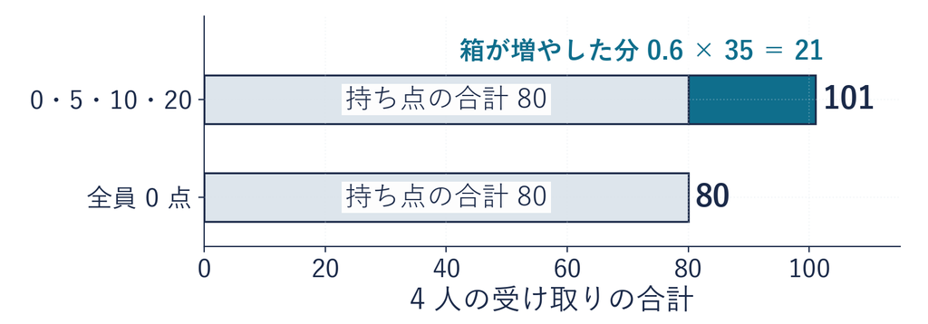

手元の合計

$80 - 35$

$= 45$

持ち点 4 人分から、入れた点を引く

戻る分の合計

$14 \times 4$

$= 56$

入れた 35 点の 1.6 倍

4 人の合計

$45 + 56$

$= 101$

2 つを足す

並べ直す

$101$

$= (80 - 35) + 1.6 \times 35$

入れた 35 は手元から消え、1.6 倍で戻る

$101$

$= 80 + 0.6 \times 35$

差し引き (1.6 − 1) ＝ 0.6 倍（棒の 80 ＋ 21）

この式は、あとでもう一度使う

## 教室の組 4 の受け取り

2026年度のデータ

今度は実験の日の教室の組で、同じ式を使う  
（1 回目・49 件 → 12 組と余り 1 人・その組 4）

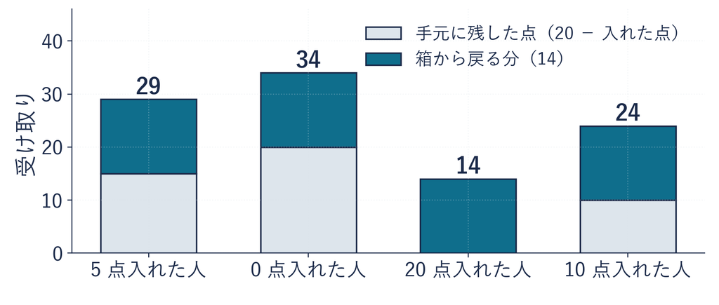

- **戻る分**：1.6 × 35 ÷ 4 ＝ 14（入れた点は 5・0・20・10）
- **4 人の合計**：101 ＝ 80 ＋ 0.6 × 35

前の例と同じ点の組。残りの組は、このあとのトピックで開ける

## 受け取りの関数の写経

```python
def payoff(contribs, m=1.6):                # 受け取りの関数
    back = m * sum(contribs) / len(contribs)  # 戻る分
    return [20 - c + back for c in contribs]  # 手元 ＋ 戻る分

p = payoff([0, 5, 10, 20])                  # 4人の例
q = payoff([1, 5, 10, 20])                  # 1人目だけ1点増やす
print(p, sum(p))
print([round(b - a, 1) for a, b in zip(p, q)], round(sum(q) - sum(p), 1))
```

| 行 | 部品 | 中身 |
| --- | --- | --- |
| 1 | **① 名前と渡す物** | payoff に 4 人の点のリスト contribs を渡す （m は箱の倍率・書かなければ 1.6） |
| 2 | **② 戻る分** | 倍率 × 合計 ÷ 人数（sum は合計・len は人数） |
| 3 | **③ 受け取り** | for c in contribs で 4 人の点を 1 つずつ c に入れ、 20 − c ＋ back を並べる |
| 5-6 | **④ 2 つの組** | 例の 4 人と、1 人目だけ 1 点増やした組 |
| 7-8 | **⑤ 表示** | 受け取りと合計／差と合計の差（round で小数 1 桁に） zip(p, q) は p と q を同じ人どうし組にする |

## 受け取りの関数の写経と実行

1. **＋ コード**で  
   セルを足す
2. p.14 のコードを  
   上から写す
3. **▶** か **Shift + Enter** で実行  
   （Mac は Shift + return）
4. 2 行の出力で  
   受け取りと差を見る

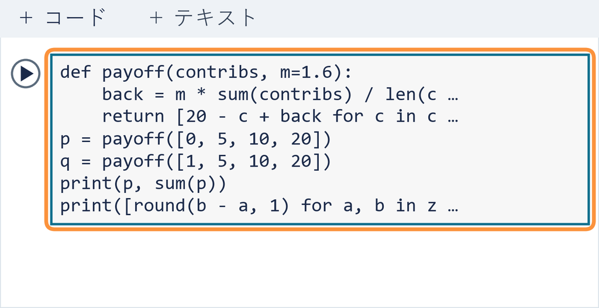

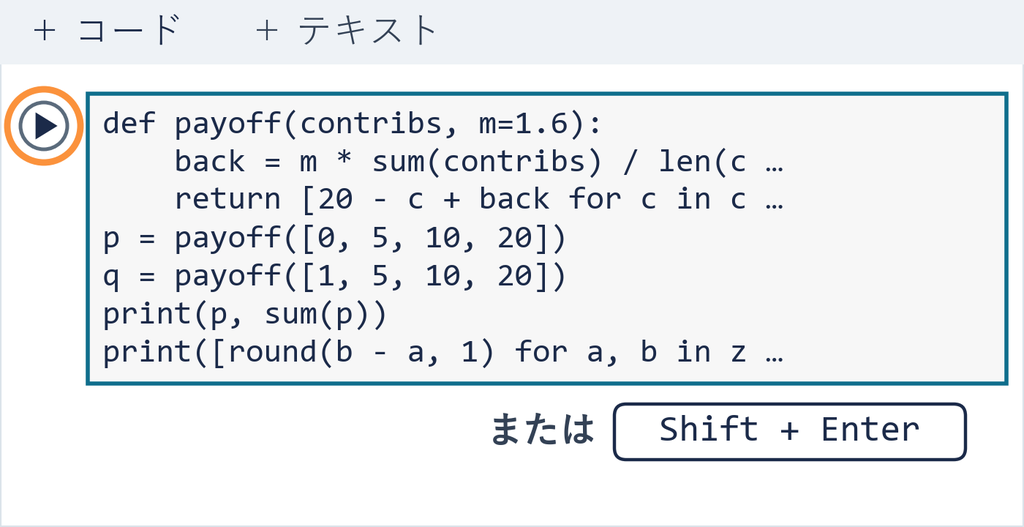

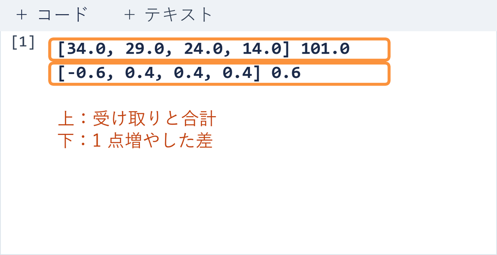

⏸ PAUSE 動画を止めて $5$ 分。2 行が出たら再生に戻る

## 演習 1：3 人目を 1 点増やす

p.15 の出力 [-0.6, 0.4, 0.4, 0.4] 0.6

演習 1

1 点増やす人を替えても、効き目は同じか

```python
p = payoff([0, 5, 10, 20])                  # 4人の例
q = payoff([1, 5, 10, 20])                  # ← ここを書き換える
print(p, sum(p))
print([round(b - a, 1) for a, b in zip(p, q)], round(sum(q) - sum(p), 1))
```

1. **書き換える**：**＋ コード**で足したセルに同じ 4 行を写し、2 行目の  
   先頭の 1 を 0 に戻し、3 つめの 10 を 11 にする（3 人目だけ 1 点増やす）
2. **予想する**：3 人目の受け取りの変化は（−0.6／−1／＋0.4）
3. **終わり**：2 行が出たら、ノートの演習 1 の答え欄（テキストセル）に  
   3 人目の変化と 4 人の合計の変化を書く

⏸ PAUSE 動画を止めて $5$ 分。2 行が出たら再生に戻る

## 演習 1 の答え

q = payoff([0, 5, 11, 20])  
[34.0, 29.0, 24.0, 14.0] 101.0  
[0.4, 0.4, -0.6, 0.4] 0.6

- **3 人目**：24 → 23.4（−1 ＋ 0.4 ＝ −0.6）
- **他の 3 人**：0.4 ずつ増える（34.4・29.4・14.4）
- **4 人の合計**：101 → 101.6（0.6 増える）

誰が入れても、入れた人は 0.6 減り、4 人の合計では 0.6 増える

## まとめ

- **公共財**：皆が同時に使えて、払わない人を締め出しにくいもの
- **利得関数**：利得（受け取り）を返す関数  
  （20 − 自分が入れた点）＋ 1.6 × 4 人が入れた点の合計 ÷ 4
- **1 点の効き目**：自分 −0.6・他の 3 人 ＋0.4 ずつ・4 人 ＋0.6

**分析する人として**  
言えること：1 点入れると、自分は 0.6 減り、4 人では 0.6 増える  
まだ言えないこと：皆が多く入れるとき、自分も入れたほうが得か  
これを次のトピックで見る

経済プログラミング特論II

第5回 — Topic02

支配戦略と社会的ジレンマ

相手が何をしても、いちばん得な選び方は変わらない

## 今日の道のり

**今日のあなた**：公共財ゲームの結果を読んで報告する人  
**今日のゴール**：箱に入れた 1 点は、自分の得か、皆の得か  
計算の答えと、実験の日の教室の数で答える

1

受け取りを式にする

実習：写経 受け取りの関数

演習 1 3 人目を 1 点増やす

2

他の人を固定する

実習：写経 自分の点の表

演習 2 他の 3 人を 5 点に

3

教室の組を読む

実習：写経 4 人組と受け取り

演習 3 2 回目で同じことを

4

計算の答えと比べる

実習：写経 上げ下げを数える

演習 4 平均より下で下げた人

いまココ。他の人の点を**固定して**比べる

## このトピックで学ぶこと

- **ここまで**：1 点入れると、自分は 0.6 減り、4 人の合計は 0.6 増える
- **でも**：実験の日、あなたは他の人の点を知らずに入れた  
  皆が入れるなら自分も、とも、入れなくても戻る、とも思える
- **問い**：他の 3 人が 20 点ずつと分かっていたら、あなたなら何点入れるか  
  **分析する人として**：自分の得と皆の得のずれを確かめる
- **進め方**：前半は他の 3 人を 0・10・20 点に固定して、表と線で比べる  
  後半で教室の 49 人の数で確かめ、Colab で表にする

そこで、他の 3 人の点を**固定して**、自分の点だけを動かしてみる

## 他の 3 人が 20 点ずつのときの 1 点

他の 3 人は 20 点ずつ入れると分かっている  
あなたが得なのは

- **①** 20 点入れる
- **②** 0 点にする
- **③** どちらも同じ

動画を止めて、①〜③から 1 つ選んで、少し考えてから再生

## 他の 3 人ごとの受け取りの表

他の 3 人の点を 1 つ決めるごとに、自分が 0 点と 20 点の受け取りを出す  
（前のトピックの受け取りの式に、数を入れるだけ）

[figure not shown]

どの行も 0 点のほうが 12 多い（20 点 × 0.6）。入口の答えは ②

## 他の 3 人ごとの自分の受け取りの線

[figure not shown]

- **傾き**：3 本とも同じ。自分が 1 点入れるごとに 0.6 下がる
- **他の 3 人の点**：線を上下にずらすだけ。左端の 0 点がいつもいちばん高い

## 支配戦略

**支配戦略：相手が何をしても、いちばん得な選び方は変わらない**

定義

**支配戦略**相手（ここでは他の 3 人）が何を選んでも  
自分にとっていちばん得な選び方

- **公共財ゲーム**：0 点。どの線でも 0 点がほかの点より上（ほかを支配する）
- **理由**：1 点入れるたびに、自分は必ず 0.6 減る
- **美人投票**（前に出てきた）：皆の平均しだいで、いちばん得な数が変わった

## 社会的ジレンマ

**社会的ジレンマ：一人ひとりの正解を足すと、皆の損になる**

定義

**社会的ジレンマ**一人ひとりが自分に得な選び方をすると、皆の得から離れること

**皆の得**4 人の受け取りの合計（下の図の縦軸）

[figure not shown]

線の上は、自分だけが点を動かしたとき。2 つの端を結ぶのは、4 人全員が変わったとき

## Q&A

Q1 他の人がたくさん入れるなら、自分も入れたほうが得？

他の人の点は、自分の線を**上にずらすだけ**  
傾きは同じ。自分の 1 点は、いつも 0.6 減らす

Q2 1.6 倍でなくても、自分は減り 4 人の合計は増える？

0.8 倍：自分 −0.8・4 人の合計 −0.2（どちらも減る）  
4 倍：自分 0・4 人の合計 ＋3  
6 倍：自分 ＋0.5・4 人の合計 ＋5  
逆を向くのは、1 倍より大きく 4 倍より小さいとき  
（4 は人数で割る分）

## ナッシュ均衡

**ナッシュ均衡：誰も一人では動きたくない組み合わせ**

定義

**ナッシュ均衡**どの一人も、自分だけ選び方を変えても得をしない  
4 人の点の組み合わせ（例 0・0・0・0）

なぜ名前が要るか：支配戦略の無いゲーム（美人投票など）でも、この組み合わせは探せる

| 出発点 | 一人だけ変える | その人の受け取り | 動きたくなるか |
| --- | --- | --- | --- |
| 全員 0 点 | 20 点入れる | 20 → 8 | ならない |
| 全員 20 点 | 0 点にする | 32 → 44 | なる |

支配戦略は一人の選び方、ナッシュ均衡は全員の選び方の組み合わせ

全員 0 点がナッシュ均衡。それは全員 20 点より、皆に損

## 自分だけ 0 にしたときの教室の 49 人

2026年度のデータ

今度は実験の日の教室の 49 人で（1 回目）。自分だけ 0 点にしていたら

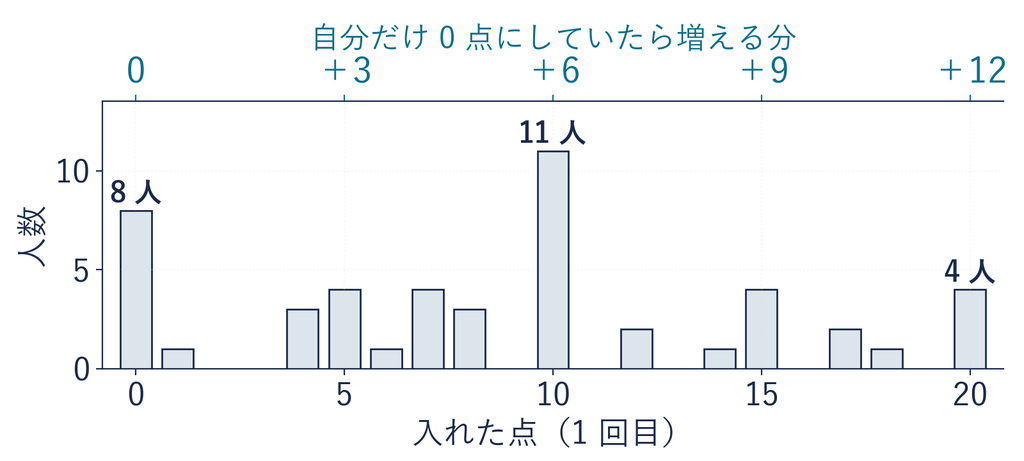

- **増える分**：0.6 × 入れた点。他の人の点を見なくても決まる（他の人の点はそのまま）
- **49 人のうち 41 人が増える**：平均 ＋5.28（20 点の 4 人は ＋12）
- **その分**：組の他の 3 人は 0.4 × 入れた点ずつ減る

## デモ：他の 3 人を変える

数の話

受け取り ＝ 20 − 自分が入れた点 ＋ 1.6 ×  
4 人が入れた点の合計 ÷ 4

- **何を見るか**：自分の点を 0〜20 で動かしたときの受け取り
- **図の意味**：左＝自分・右＝4 人の受け取りの合計
- **操作**：他の 3 人のボタン  
  （5・10・20＝3 人がそれぞれ）・自分の点のスライダ

ミッション 自分の受け取りがいちばん多い点と、  
4 人の合計がいちばん多い点を別々に探す

※ 次のスライドへ進むときは、デモの枠の外を一度クリックしてから ← → キーを押す

[interactive chart not shown]

## 自分の得と皆の得の調べ方

手順

1. 他の人の点を固定する
2. 自分の点を動かし  
   自分の受け取りと 4 人の合計の変化を出す
3. 向きが逆（1 点入れると自分は減り  
   4 人の合計は増える）なら、社会的ジレンマ

次の写経で、他の 3 人を 20 点ずつに固定して、この手順をコードで行う

## 自分の点の表の写経

```python
others = [20, 20, 20]                         # 他の3人を固定する
for x in [0, 10, 20]:                         # 自分の点を 0・10・20 と動かす
    p = payoff([x] + others)                  # 自分を先頭にした4人の受け取り
    print(x, round(p[0], 1), round(sum(p), 1))  # 自分の点・自分・4人の合計
```

| 行 | 部品 | 中身 |
| --- | --- | --- |
| 1 | **① 他の 3 人** | 3 人の点のリストを固定する |
| 2 | **② 自分の点** | x に 0・10・20 を 1 つずつ入れて、下の 2 行をくり返す |
| 3 | **③ 4 人の受け取り** | [x] + others は自分を先頭にした 4 人のリスト （＋ はリストをつなぐ。数の足し算ではない）。 payoff は受け取りの式のトピックで作った関数 |
| 4 | **④ 表示** | 自分の点・自分の受け取り p[0]・4 人の合計 sum(p) （round で小数 1 桁に丸める） |

## 自分の点の表の写経と実行

1. **＋ コード**で  
   セルを足す
2. p.33 のコードを  
   上から写す
3. **▶** か **Shift + Enter** で実行  
   （Mac は Shift + return）
4. 3 行の出力で  
   自分と 4 人の合計を見る

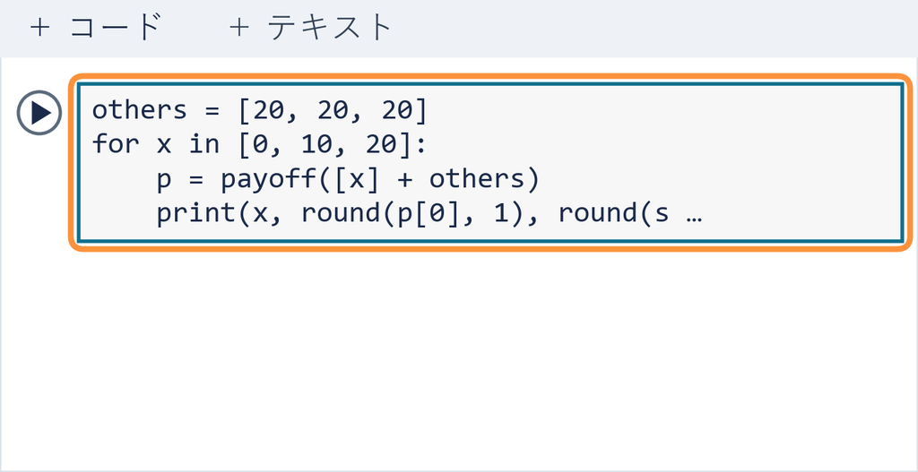

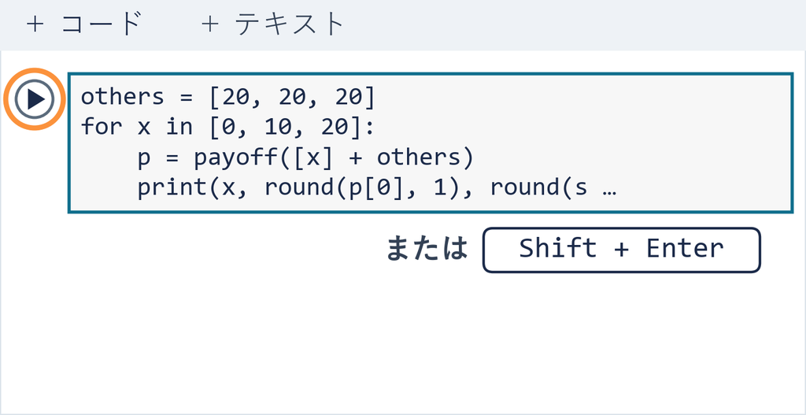

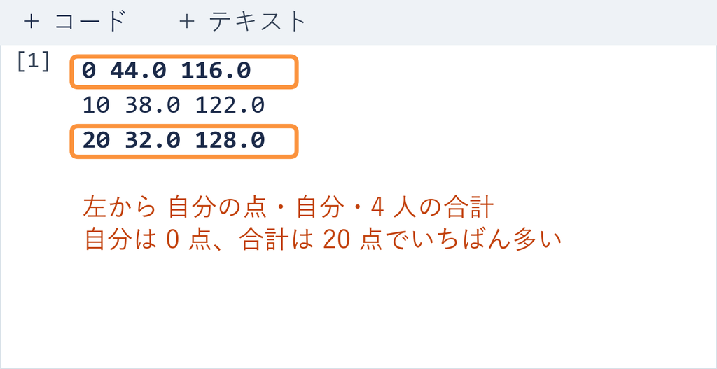

⏸ PAUSE 動画を止めて $5$ 分。3 行が出たら再生に戻る

## 演習 2 他の 3 人の 5 点

p.34 の出力 0 44.0 116.0 ／ 20 32.0 128.0

演習 2

他の 3 人が 5 点ずつなら、  
自分と 4 人の合計がいちばん多い点はどこか

```python
others = [20, 20, 20]                         # ← ここを書き換える
for x in [0, 10, 20]:
    p = payoff([x] + others)
    print(x, round(p[0], 1), round(sum(p), 1))
```

1. **書き換える**：**＋ コード**で足したセルに同じ 4 行を写し  
   1 行目を「他の 3 人が 5 点ずつ」に
2. **予想する**：自分の受け取りがいちばん多い自分の点は（0／10／20）
3. **終わり**：3 行が出たら、ノートの演習 2 の答え欄（テキストセル）に  
   2 つ書く：自分がいちばん得な点と、4 人の合計がいちばん多い自分の点

⏸ PAUSE 動画を止めて $5$ 分。3 行が出たら再生に戻る

## 演習 2 の答え

others = [5, 5, 5]  
0 26.0 89.0  
10 20.0 95.0  
20 14.0 101.0

- **自分がいちばん得**：0 点の 26（20 点なら 14）
- **4 人の合計がいちばん多い**：自分 20 点の 101（0 点なら 89）

他の 3 人が何点でも、自分の得は 0 点、4 人の合計は 20 点でいちばん多い

## まとめ

- **支配戦略**：相手が何を選んでも、  
  自分にとっていちばん得な選び方（ここでは 0 点）
- **社会的ジレンマ**：一人ひとりが自分に得な選び方を  
  すると、皆の得から離れること
- **ナッシュ均衡**：どの一人も、  
  自分だけ変えても得をしない組み合わせ（ここでは全員 0 点）

**分析する人として**  
言えること：自分のためなら 0 が答え。皆がそう選ぶと、皆が損をする  
まだ言えないこと：実験の日の教室で、入れた人は損をしたのか  
これを次のトピックで見る

経済プログラミング特論II

第5回 — Topic03

個人の利得と集団の利得

組の中では入れない人が得、組どうしでは入れた組が得

## 今日の道のり

**今日のあなた**：公共財ゲームの結果を読んで報告する人  
**今日のゴール**：箱に入れた 1 点は、自分の得か、皆の得か  
計算の答えと、実験の日の教室の数で答える

1

受け取りを式にする

実習：写経 受け取りの関数

演習 1 3 人目を 1 点増やす

2

他の人を固定する

実習：写経 自分の点の表

演習 2 他の 3 人を 5 点に

3

教室の組を読む

実習：写経 4 人組と受け取り

演習 3 2 回目で同じことを

4

計算の答えと比べる

実習：写経 上げ下げを数える

演習 4 平均より下で下げた人

いまココ。教室の組を、組の中と組どうしに**分けて**読む

## このトピックで学ぶこと

- **ここまで**：自分のためなら 0 点が答え  
  皆が 0 点を選ぶと、受け取りは全員 20 で皆が損
- **でも**：実験の日、あなたも共同の箱に点を入れた  
  入れた自分が損をしたのかは、まだ数えていない
- **問い**：入れたあなたは、損をしたのか  
  **分析する人として**：同じ組の人と別の組の人の、どちらと比べるか
- **進め方**：前半は手で追える 2 組で、組の中と組どうしを比べる  
  後半で教室の 12 組に当て、Colab で組ごとに出す

そこで、組の中と組どうしを**分けて**、受け取りを比べてみる

## 同じ組の中の受け取り

同じ組の 4 人で、受け取りがいちばん多いのは

- **①** いちばん入れた人
- **②** いちばん入れなかった人
- **③** 組による

動画を止めて、①〜③から 1 つ選んで、少し考えてから再生

## 2 組の受け取りの表

手で追える 2 組で、同じ組の 4 人を比べる

[figure not shown]

戻る分は 4 人で同じ。入れなかった人ほど多い。入口の答えは ②

## 2 組の平均の比べ方

[figure not shown]

- **組の平均**：A は入れた点 8.75 で受け取り 25.25 ／ B は 2.5 で 21.5
- **人どうし**：A の 20 点の人（14）は、B の 0 点の人（24）より少ない

組どうしは、組の平均で比べる（人どうしではない）

一人の受け取りには、組の他の人の点が混ざる。組そのものの得は、組の全員をならした平均で比べる

## 組の平均の受け取り

**組の中では入れない人が得、組どうしでは入れた組が得**

**個人の利得**自分の受け取り（組の中で比べる）

**集団の利得**組の受け取り（組はどれも 4 人なので平均で比べる）

定義

**組の平均の受け取り**20 ＋ 0.6 × 組の平均拠出

**組の平均拠出**組の 4 人が入れた点の平均

**受け取りの式のトピック**：4 人の合計 ＝ 80 ＋ 0.6 × 4 人が入れた点の合計

**4 で割る**：1 人あたりにする。80 ÷ 4 ＝ 20 ／ 入れた点の合計 ÷ 4 ＝ 組の平均拠出

**2 組で**：A 20 ＋ 0.6 × 8.75 ＝ 25.25 ／ B 20 ＋ 0.6 × 2.5 ＝ 21.5

**部品で**：手元の平均 20 − m ＋ 戻る分 1.6 m ＝ 20 ＋ 0.6 m（m は組の平均拠出）

くわしい導き方は配布資料の付録に

## 1 回目の拠出の分布

2026年度のデータ

今度は実験の日の教室で（1 回目・教室・授業内の 49 人）

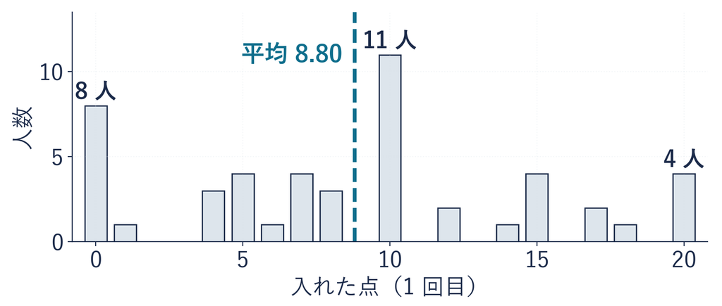

0 点を選んだのは 49 人中 8 人。平均は 8.80

## 12 組の入れた点と受け取り

2026年度のデータ

4 人組は、授業の前に決めた手順（seed＝並べ替えを決める番号）で、  
授業のあとに組んだ（12 組と余り 1 人）

[figure not shown]

- **1 本の線＝1 組**：どの線も右下がり（入れた点が 1 多いと 1 少ない）
- **12 組すべて**：いちばん入れなかった人（橙の点）が、いちばん多く受け取った

## 入れないのが正解という読み違い

2026年度のデータ

✕ 組の中の順位だけを見る

得をしたのは入れなかった人  
だから入れないのが正解？

○ 皆がその答えを選ぶと

全員が入れなければ、全員 20  
組に入った 48 人の平均は 25.26

入れなかった人が 20 を超えたのは、同じ組の誰かが入れたから

## 組の平均の受け取りの線

2026年度のデータ

[figure not shown]

- **12 組の点**：どれも 20 ＋ 0.6 × 組の平均拠出 の線の上
- **組の平均の受け取り**：21.95〜28.70（どの組も 20 より多い）

## 同じ点の人の受け取りの幅

2026年度のデータ

[figure not shown]

- **0 点の 8 人**：25.2〜34.0 ／ **20 点の 4 人**：14.0〜23.2
- **いちばん多い 37.2**：6 点入れた人（他の 3 人は 12・20・20）

自分の受け取りは、自分の点だけでなく、組の他の 3 人の点にも左右される

## デモ：教室の 4 人組

数の話

組の平均の受け取り ＝ 20 ＋ 0.6 × 組の平均拠出

- **何を見るか**：1 回目・教室の 48 人を 12 組に分けたときの受け取り
- **図の意味**：横＝入れた点・縦＝受け取り・線 1 本＝  
  1 組・大きい点＝組の平均
- **操作**：全部・組 1〜12 のボタン

ミッション 組の平均がいちばん低い組で、  
いちばん多く受け取った人の点を探す

※ 次のスライドへ進むときは、デモの枠の外を一度クリックしてから ← → キーを押す

[interactive chart not shown]

## 教室の組の読み方

手順

1. 読む集団を決める（教室・授業内の回答  
   動画で答えた人・締切後は入れない）
2. 分布と平均を出す
3. 決めた seed（並べ替えを決める番号）で  
   4 人組を組み、受け取りを出す
4. 組の中の順位と、組どうしの平均を分けて読む

次の写経で、STEP 3・4 をコードで行う

## 4 人組と受け取りの写経

```python
r, seed = r1, 20261005                   # 1回目の拠出と seed
groups, pay = group_and_payoff(r, seed)  # 4人組と一人ずつの受け取り
for g in groups:                         # 組ごとにくり返す
    cs = [r[i] for i in g]               # 組の4人が入れた点
    ps = [round(pay[i], 1) for i in g]   # 組の4人の受け取り
    print(cs, ps, round(sum(ps) / len(ps), 2))
```

| 行 | 部品 | 中身 |
| --- | --- | --- |
| 1 | **① データと seed** | r1 は 1 回目の拠出。seed は並べ替えの番号 （実験の日の日付 20261005） |
| 2 | **② 4 人組と受け取り** | 配布の道具。groups は組ごとの行番号、 pay は一人ずつの受け取り |
| 3 | **③ 組ごと** | g に 1 組の 4 人の行番号を入れて、下の 3 行をくり返す |
| 4-5 | **④ 組の 4 人** | cs（入れた点の並び）に r[i]、ps（受け取りの並び）に pay[i] |
| 6 | **⑤ 表示** | 入れた点・受け取り・組の平均の受け取り（合計 ÷ 人数） |

先に、ノートの段 3 の準備のセル 2 つを実行（データは manaba の URL か CSV 2 本）

## 4 人組と受け取りの写経と実行

1. **＋ コード**で  
   セルを足す
2. p.53 のコードを  
   上から写す
3. **▶** か **Shift + Enter** で実行  
   （Mac は Shift + return）
4. 12 行の出力で  
   組ごとの受け取りを見る

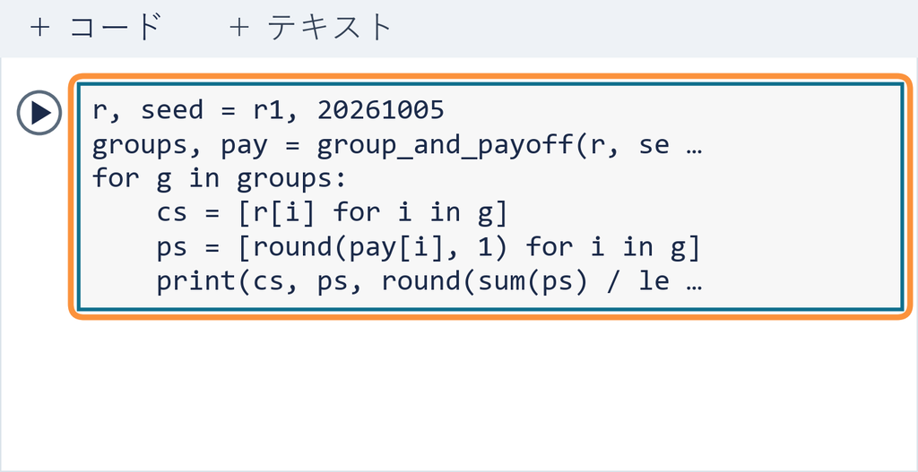

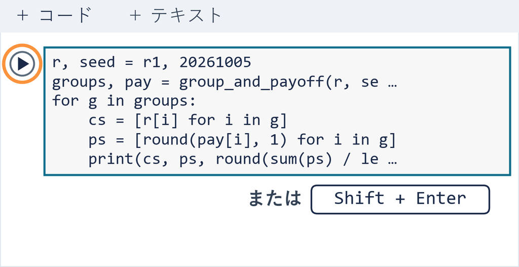

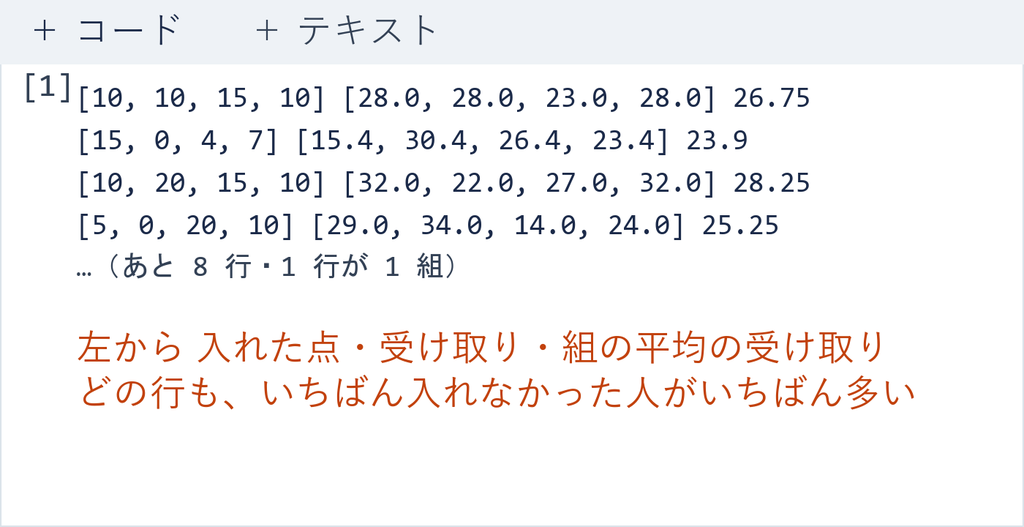

⏸ PAUSE 動画を止めて $5$ 分。12 行が出たら再生に戻る

## 演習 3：2 回目で同じことを

演習 3

2 回目でも、入れなかった人ほど受け取りが多いか

```python
r, seed = r1, 20261005                   # ← ここを書き換える
groups, pay = group_and_payoff(r, seed)
for g in groups:
    cs = [r[i] for i in g]
    ps = [round(pay[i], 1) for i in g]
    print(cs, ps, round(sum(ps) / len(ps), 2))
```

1. **書き換える**：**＋ コード**で足したセルに同じ 6 行を写し  
   1 行目を r, seed = r2, 20261006 にする（r2＝平均 8.80 を見た後の点）
2. **予想する**：12 組のどこでも、いちばん入れなかった人がいちばん多いか
3. **終わり**：12 行が出たら、ノートの演習 3 の答え欄に 2 つ書く  
   成り立つかと、組の平均の受け取りの範囲

⏸ PAUSE 動画を止めて $5$ 分。12 行が出たら再生に戻る

## 演習 3 の答え

2026年度のデータ

12 行のうち、組の平均がいちばん高い組と低い組  
（自分の出力の 4 行目と 5 行目）

r, seed = r2, 20261006  
[7, 20, 5, 8] [29.0, 16.0, 31.0, 28.0] 26.0  
[4, 7, 0, 7] [23.2, 20.2, 27.2, 20.2] 22.7

- **12 組とも**：入れた点がいちばん小さい人がいちばん多い  
  （同じ点の 2 人は 2 人とも。2 回目は 48 人なので余り 0）
- **組の平均の受け取り**：22.70〜26.00（1 回目は 21.95〜28.70）

どちらの回も、組の中は入れなかった人ほど多く、組の平均は 1 本の線の上

## まとめ

- **組の中**：入れなかった人ほど受け取りが多い（戻る分は 4 人で同じ）
- **組の平均の受け取り**：20 ＋ 0.6 × 組の平均拠出
- **自分の受け取り**：自分の点だけでなく、  
  組の他の 3 人の点にも左右される
- **入れたあなたは損をしたか**：組の中では損。でも入れた人のおかげで、  
  組の平均は 12 組とも 20 を超えた

**分析する人として**  
言えること：組の中では入れない人が得、組どうしでは入れた組が得  
まだ言えないこと：計算の答え 0 と教室の平均 8.80 のずれの意味  
これを次のトピックで見る

経済プログラミング特論II

第5回 — Topic04

理論予測と観測行動の区別

計算の答えは 0、教室の平均は 8.80

## 今日の道のり

**今日のあなた**：公共財ゲームの結果を読んで報告する人  
**今日のゴール**：箱に入れた 1 点は、自分の得か、皆の得か  
計算の答えと、実験の日の教室の数で答える

1

受け取りを式にする

実習：写経 受け取りの関数

演習 1 3 人目を 1 点増やす

2

他の人を固定する

実習：写経 自分の点の表

演習 2 他の 3 人を 5 点に

3

教室の組を読む

実習：写経 4 人組と受け取り

演習 3 2 回目で同じことを

4

計算の答えと比べる

実習：写経 上げ下げを数える

演習 4 平均より下で下げた人

いまココ。計算の答えを**基準**にして、教室の数とのずれを測る

## このトピックで学ぶこと

- **ここまで**：自分の受け取りだけを考えるなら、計算の答えは 0 点  
  組の中でも、入れた人ほど受け取りが少ない
- **でも**：実験の日、教室で 0 点を選んだのは 49 人中 8 人  
  あなたも、0 点より多く入れたかもしれない
- **問い**：計算の答え 0 点と、教室の平均 8.80 のずれ  
  **分析する人として**：このずれを、どう読んで報告するか
- **進め方**：前半は手で追える 5 人で、1 回目と 2 回目の動きを読む  
  後半で教室の 46 人に当て、Colab で上げ下げを数える

そこで、計算の答えを**基準**にして、ずれを測ってみる

## 計算の答えと教室の平均

2026年度のデータ

教室の 49 人のうち 0 点は 8 人、平均は 8.80  
この数から言えるのは

- **①** 多くの人が、計算を間違えた
- **②** 多くの人の目的は、自分の受け取りだけではなかったかもしれない
- **③** 教室の人は皆、利他的（他の人の得も目的に入れる）

動画を止めて、①〜③から 1 つ選んで、少し考えてから再生

## 理論予測と観測

**理論予測の目的：観測とのずれの大きさと向きを測ること**

定義

**理論予測**ある目的を仮定したときの計算の答え

**観測**データに書いてあること

**説明**なぜそうなったかの候補

- **今回**：理論予測は 0 点（目的は自分の受け取りだけ）、観測は平均 8.80
- **ずれたら**：まず目的の仮定を見直す。入口の答えは ②  
  （① でないことは、あとの Q&A で確かめる）

## 5 人の 1 回目と 2 回目

手で追える 5 人で。2 回目の前に見た平均は 9  
（見たのは教室全体の平均。この 5 人の平均ではない）

[figure not shown]

- **2 回目**：集計情報を見た後の再選択（見たのは平均だけ）
- **上げた** C ／ **下げた** A・D ／ **同じ** B・E

## 説明の候補

| 人 | 1 回目 → 2 回目 | 平均 9 より | 皆に合わせる | 損に気づいた |
| --- | --- | --- | --- | --- |
| A | 15 → 10 | 上 | ○ | ○ |
| B | 0 → 0 | 下 | ×（上げるはず） | ○（0 のまま） |
| C | 4 → 8 | 下 | ○ | ×（下げるはず） |
| D | 20 → 12 | 上 | ○ | ○ |
| E | 10 → 10 | 上 | ×（下げるはず） | ×（下げるはず） |

皆に合わせる：平均より上なら下げ、下なら上げる  
損に気づいた（入れると自分は 0.6 減ると気づいた）：  
0 のほうへ下げる（すでに 0 なら 0 のまま）  
E はどちらでもない。動かない人（いつも同じ点）という 3 つ目の候補もある

上げた C を説明できるのは「合わせる」だけ。上げた人が候補を分ける

## 自己申告の 1 回目と 2 回目

2026年度のデータ

今度は実験の日の教室で（教室・授業内の 46 本）  
左＝自己申告の 1 回目（2 回目のフォームに自分で書いた 1 回目の点。空欄の 2 人は外した）

[figure not shown]

- **下げた 24・上げた 11・同じ 11**（0 → 0 が 4・20 → 20 が 1）
- **教室の平均**：8.80 → 7.19（1 回目 49 人・2 回目 48 人）

## 見た平均の上と下からの動き

2026年度のデータ

[figure not shown]

- **上げた 11 人**：10 人は 1 回目が見た平均 8.80 より下から
- **下げた 24 人**：19 人は上から、5 人は下から

「合わせる」に近い形。ただし下げた人は「損に気づいた」でも説明可能

## Q&A

2026年度のデータ

Q1 計算を間違えただけ？

確認問題に正答した 42 人  
の平均も 8.62  
計算違いだけとは言えない

確認問題：自分だけ 20 点・他の 3 人が 0 点なら  
自分の受け取りは？（答え 8）

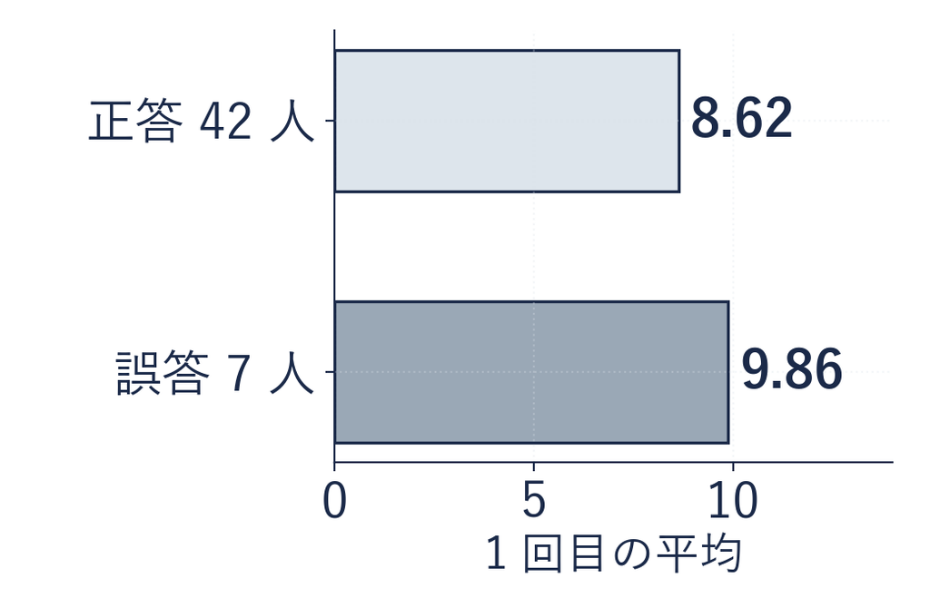

Q2 理論の答えが当たらないなら、理論は要らない？

0 という基準があるから  
8.80 は、自分の受け取りだけを目的に  
正しく計算した答えとは一致しないと分かる

## よくある失敗 理由の決めつけ

Q1 0 より多く入れた人は、利他的だった？

計算違い・他の人も入れてくれるという期待・公平感の  
どれでも、同じ 8.80 になりうる。数だけでは、  
理由は 1 つに決まらない

Q2 2 回目に下がったのは、平均を見せたせい？

2 回目であること・ルールへの慣れも、同時に変わった  
どれが効いたかは、この数だけでは分けられない

利他的：他の人の得も、自分の選び方の目的に入れること

## 観測の読み方

手順

1. 観測を数で 1 文にする
2. 理論予測との差を書く
3. 説明の候補を 2 つ以上と  
   候補を分ける次の観測を書く
- **教室では**：理論予測なら全員 0 点のはずが  
  49 人中 41 人は 0 点以外
- **分ける観測の例**：理由を尋ねる設問・平均を見せない 2 回目

## この授業の外で 前後比較のニュース

ニュース「キャンペーンの後、寄付が増えた」

STEP 1観測：キャンペーンの前より後のほうが、寄付が多い

STEP 2比べる相手との差：キャンペーンの無い年の  
同じ時期と比べる

STEP 3候補：キャンペーンを見た／年末で寄付が増える時期

分ける観測キャンペーンを見なかった人の寄付も、増えたか

## 上げ下げの数え方の写経

```python
pairs = [(a, b) for a, b in zip(s1, r2) if a is not None]  # 空の行を外す
up = [a for a, b in pairs if b > a]          # 上げた人の1回目
down = [a for a, b in pairs if b < a]        # 下げた人の1回目
same = [a for a, b in pairs if b == a]       # 同じ人の1回目
print(len(pairs), len(up), len(down), len(same))
shown = round(sum(r1) / len(r1), 2)          # 2回目の前に見た平均
print(len([a for a in up if a < shown]))     # 上げた人で、平均より下から
print(len([a for a in down if a > shown]))   # 下げた人で、平均より上から
```

| 行 | 部品 | 中身 |
| --- | --- | --- |
| 1 | **① 1 人ずつ組に** | s1 と r2 を 1 人ずつ組にし、空（None）の行を外す |
| 2-4 | **② 上げ下げ** | b（2 回目）が a（1 回目）より大きい・小さい・同じ人の a |
| 5 | **③ 数える** | len で人数。線の本数・上げた・下げた・同じ |
| 6 | **④ 見た平均** | 1 回目の平均を小数 2 桁に丸めた数（2 回目の前に見せた数） |
| 7-8 | **⑤ 上と下** | 上げた人で平均より下から・下げた人で平均より上からの人数 |

準備のセルを先に実行。r1：1 回目の拠出（49 人）  
r2：2 回目の拠出（48 人）／s1：自己申告の 1 回目（r2 と同じ並び）

## 上げ下げの数え方の写経と実行

1. **＋ コード**で  
   セルを足す
2. p.71 のコードを  
   上から写す
3. **▶** か **Shift + Enter** で実行  
   （Mac は Shift + return）
4. 3 行の出力で  
   上げ下げの人数を見る

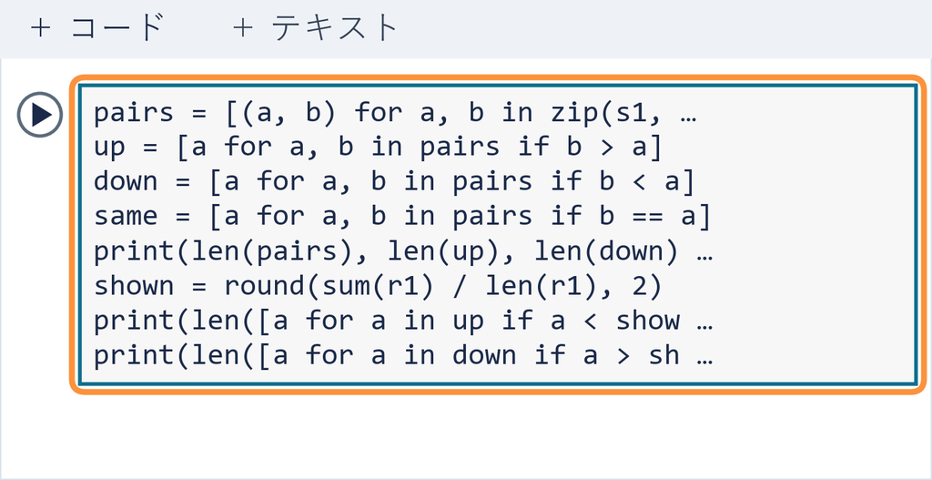

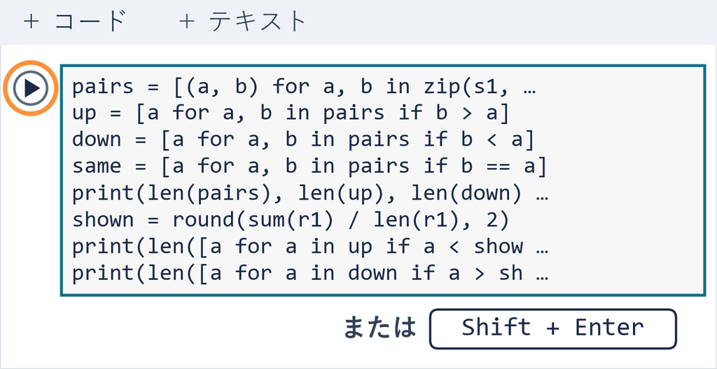

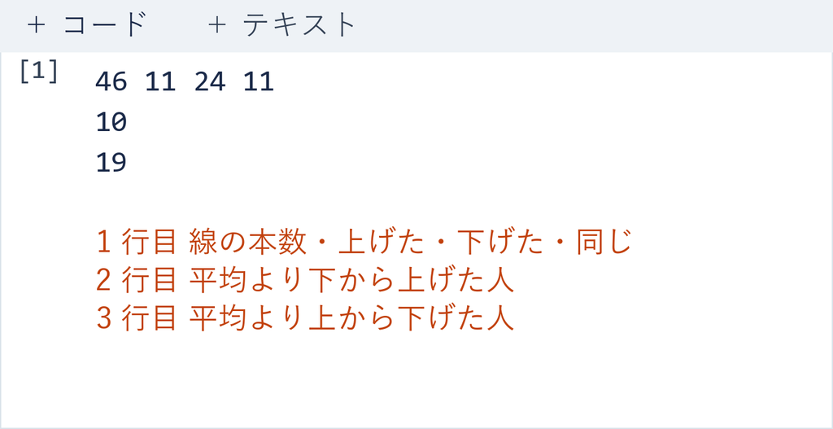

⏸ PAUSE 動画を止めて $5$ 分。3 行が出たら再生に戻る

## 演習 4 平均より下で下げた人

演習 4

下げた人のうち、1 回目が見た平均より下だった人は何人か

```python
pairs = [(a, b) for a, b in zip(s1, r2) if a is not None]
up = [a for a, b in pairs if b > a]
down = [a for a, b in pairs if b < a]
same = [a for a, b in pairs if b == a]
print(len(pairs), len(up), len(down), len(same))
shown = round(sum(r1) / len(r1), 2)
print(len([a for a in up if a < shown]))
print(len([a for a in down if a > shown]))   # 下げた人で平均より上 → 下 に変える
```

1. **書き換える**：**＋ コード**で足したセルに同じ 8 行を写し  
   （前のセルをコピーして貼ってよい）、8 行目を「平均より下」に
2. **考える**：その人たちは「皆に合わせる」で説明できるか
3. **終わり**：ノートの演習 4 の答え欄に 3 つ書く（人数・説明できるか・別の候補を 1 つ）

⏸ PAUSE 動画を止めて $5$ 分。3 つ書いたら再生に戻る

## 演習 4 の答え

2026年度のデータ

print(len([a for a in down if a < shown])) → 5

- **5 人**：7→6・8→7・1→0・5→3・5→2（どれも 8.80 より下から）
- **「合わせる」では説明できない**：平均より下なら上げるはず
- **別の候補の例**：損に気づいた（1 点入れると自分は 0.6 減る）

候補ごとに線の向きを書くと、説明できない人が見える

## まとめ

- **理論予測**：ある目的を仮定したときの計算の答え（ここでは 0 点）
- **教室の数**：上げた 11 人のうち 10 人は、見た平均 8.80 より下から
- **読み方**：観測・理論予測との差・説明の候補と分ける観測

分析する人として、この回でできるようになったこと

**受け取りの式**受け取りを式にして、1 点の効き目を出す

**他の人を固定**他の 3 人を固定して、入れないほうが得かを確かめる

**組の中と組どうし**教室の組を分けて、受け取りを比べる

**ずれを測る**計算の答えを基準に、教室の数のずれを読む

言えること：理論の答え 0 は当てるためでなく、ずれを測るため  
組の中では 0 点が得、全体では全員 20 点が得（グループ発表の準備も同じ形）  
まだ言えないこと：ルールのほうを変えたら、選び方はどう変わるか（このあと考える）  
やること：演習 1〜4 の答え欄を書いて、いつもの手順で提出